# PART 1

```python
import numpy as np
from sklearn.linear_model import LinearRegression
import pandas as pd
import matplotlib.pyplot as plt
%matplotlib inline
import seaborn as sns
from sklearn.model_selection import train_test_split # Sklearn package's randomized data splitting function
import json
from sklearn.cluster import KMeans
from scipy.stats import zscore
from sklearn.preprocessing import StandardScaler
from sklearn import svm
from sklearn.metrics import classification_report
from sklearn.decomposition import PCA
```

```python
cname = pd.read_csv("Car name.csv")
cname.shape
```

```
(398, 1)
```

```python
cAttr = pd.read_json('Car-Attributes.json')
cAttr.shape
```

```
(398, 8)
```

```python
fdata = pd.concat([cname, cAttr], axis=1)
fdata.shape
```

```
(398, 9)
```

```python
fdata.head()
```

|  | car_name | mpg | cyl | disp | hp | wt | acc | yr | origin |
| --- | --- | --- | --- | --- | --- | --- | --- | --- | --- |
| 0 | chevrolet chevelle malibu | 18.0 | 8 | 307.0 | 130 | 3504 | 12.0 | 70 | 1 |
| 1 | buick skylark 320 | 15.0 | 8 | 350.0 | 165 | 3693 | 11.5 | 70 | 1 |
| 2 | plymouth satellite | 18.0 | 8 | 318.0 | 150 | 3436 | 11.0 | 70 | 1 |
| 3 | amc rebel sst | 16.0 | 8 | 304.0 | 150 | 3433 | 12.0 | 70 | 1 |
| 4 | ford torino | 17.0 | 8 | 302.0 | 140 | 3449 | 10.5 | 70 | 1 |

```python
fdata.describe()
```

|  | mpg | cyl | disp | wt | acc | yr | origin |
| --- | --- | --- | --- | --- | --- | --- | --- |
| count | 398.000000 | 398.000000 | 398.000000 | 398.000000 | 398.000000 | 398.000000 | 398.000000 |
| mean | 23.514573 | 5.454774 | 193.425879 | 2970.424623 | 15.568090 | 76.010050 | 1.572864 |
| std | 7.815984 | 1.701004 | 104.269838 | 846.841774 | 2.757689 | 3.697627 | 0.802055 |
| min | 9.000000 | 3.000000 | 68.000000 | 1613.000000 | 8.000000 | 70.000000 | 1.000000 |
| 25% | 17.500000 | 4.000000 | 104.250000 | 2223.750000 | 13.825000 | 73.000000 | 1.000000 |
| 50% | 23.000000 | 4.000000 | 148.500000 | 2803.500000 | 15.500000 | 76.000000 | 1.000000 |
| 75% | 29.000000 | 8.000000 | 262.000000 | 3608.000000 | 17.175000 | 79.000000 | 2.000000 |
| max | 46.600000 | 8.000000 | 455.000000 | 5140.000000 | 24.800000 | 82.000000 | 3.000000 |

- For column mpg we can analyze that our 25th Percentile is 17.5 i.e 18 which means 25% of the data is less than 18. The 75th Percentile value is 29 meaning 75% of data lies below 29. One major thing to note is that there is a major difference between the 75 percentile value and maximum value which can be interpreted as the mpg feature is highly skewed and does not follow a Normal Distribution.
- For column cyl we can analyze that our 25th Percentile is 4 which means 25% of the data is less than 4. The 75th Percentile value is 8 meaning 75% of data lies below 8. Here note is that there is a no difference between the 75 percentile value and maximum value which can be interpreted as the cyl feature is not skewed and follow a Normal Distribution.
- For column disp we can analyze that our 25th Percentile is 104.25 i.e 104 which means 25% of the data is less than 104. The 75th Percentile value is 262 meaning 75% of data lies below 262. Here the major thing to note is that there is a major difference between the 75 percentile value and maximum value which can be interpreted as the disp feature is highly skewed and does not follow a Normal Distribution.
- For column wt we can analyze that our 25th Percentile is 2223.75 i.e 2224 which means 25% of the data is less than 2224. The 75th Percentile value is 3608 meaning 75% of data lies below 3608.Here we can see that there is a major difference between the 75 percentile value and maximum value which can be interpreted as the wt feature is highly skewed and does follow a Normal Distribution.
- For column acc we can analyze that our 25th Percentile is 13.82 i.e 14 which means 25% of the data is less than 14. The 75th Percentile value is 17.18 i.e. 17 meaning 75% of data lies below 17.Here thewe can see that there is a no major difference between the 75 percentile value and maximum value which can be interpreted as the acc feature is not highly skewed and does follow a Normal Distribution.
- For column yr we can analyze that our 25th Percentile is 73 which means 25% of the data is less than 73. The 75th Percentile value is 79 meaning 75% of data lies below 79.Here thewe can see that there is a no major difference between the 75 percentile value and maximum value which can be interpreted as the yr feature is not highly skewed and does follow a Normal Distribution.

```python
print("Feature-wise percentage of Null values : \n {0}".format(fdata.isnull().sum() * 100 / len(fdata)))
```

```
Feature-wise percentage of Null values :
 car_name    0.0
mpg         0.0
cyl         0.0
disp        0.0
hp          0.0
wt          0.0
acc         0.0
yr          0.0
origin      0.0
dtype: float64
```

*There Is no missing values in any Feature

```python
dupes = fdata.duplicated()
sum(dupes)
```

```
0
```

*There Is no duplicate values in any Feature

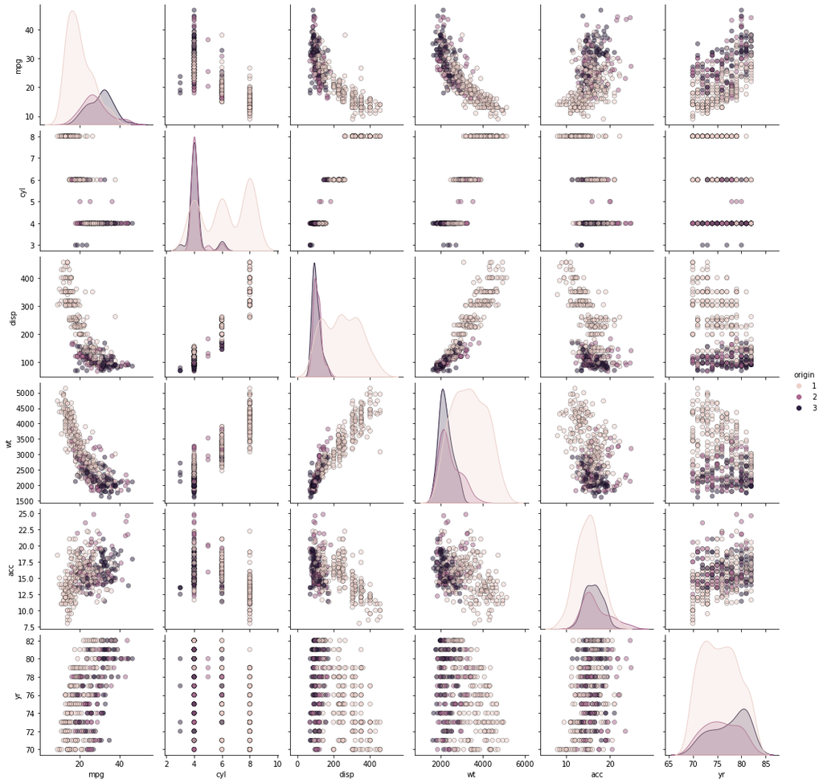

```python
sns.pairplot(fdata, hue = 'origin',plot_kws={'alpha':0.5, 'edgecolor': 'k'})
```

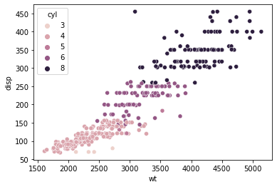

```python
sns.scatterplot(data=fdata, x="wt", y="disp", hue="cyl")
```

- First we can see here disp and wt are positively correlated with increse in wt we can observe increase in disp
- We observe that increase in the disp and wt also increase in cyl value
- The disp and wt values are hight at cyl 8
- The cyl 3 occures very low frequency
- The disp and wt values are low for cyl 3 & 4

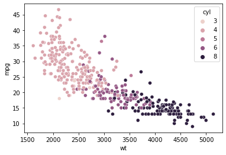

```python
sns.scatterplot(data=fdata, x="wt", y="mpg", hue="cyl")
```

- First we can see here mpg and wt are highly correlated with decrease in wt we can observe increase in mpg
- We observe that decrease in the wt also decrease in cyl value
- The mpg values are hight at cyl 4
- The cyl 3 occures very low frequency

```python
print("There is {0} variation in mpg feature of fdata : {1} ".format(fdata.mpg.nunique(),fdata.mpg.unique()))
print("There is {0} variation in cyl feature of fdata : {1} ".format(fdata.cyl.nunique(),fdata.cyl.unique()))
print("There is {0} variation in disp feature of fdata : {1} ".format(fdata.disp.nunique(),fdata.disp.unique()))
print("There is {0} variation in wt feature of fdata : {1} ".format(fdata.wt.nunique(),fdata.wt.unique()))
print("There is {0} variation in acc feature of fdata : {1} ".format(fdata.acc.nunique(),fdata.acc.unique()))
print("There is {0} variation in yr feature of fdata : {1} ".format(fdata.yr.nunique(),fdata.yr.unique()))
print("There is {0} variation in hp feature of fdata : {1} ".format(fdata.hp.nunique(),fdata.hp.unique()))
```

```
There is 129 variation in mpg feature of fdata : [18.  15.  16.  17.  14.  24.  22.  21.  27.  26.  25.  10.  11.   9.
 28.  19.  12.  13.  23.  30.  31.  35.  20.  29.  32.  33.  17.5 15.5
 14.5 22.5 24.5 18.5 29.5 26.5 16.5 31.5 36.  25.5 33.5 20.5 30.5 21.5
 43.1 36.1 32.8 39.4 19.9 19.4 20.2 19.2 25.1 20.6 20.8 18.6 18.1 17.7
 27.5 27.2 30.9 21.1 23.2 23.8 23.9 20.3 21.6 16.2 19.8 22.3 17.6 18.2
 16.9 31.9 34.1 35.7 27.4 25.4 34.2 34.5 31.8 37.3 28.4 28.8 26.8 41.5
 38.1 32.1 37.2 26.4 24.3 19.1 34.3 29.8 31.3 37.  32.2 46.6 27.9 40.8
 44.3 43.4 36.4 44.6 40.9 33.8 32.7 23.7 23.6 32.4 26.6 25.8 23.5 39.1
 39.  35.1 32.3 37.7 34.7 34.4 29.9 33.7 32.9 31.6 28.1 30.7 24.2 22.4
 34.  38.  44. ]
There is 5 variation in cyl feature of fdata : [8 4 6 3 5]
There is 82 variation in disp feature of fdata : [307.  350.  318.  304.  302.  429.  454.  440.  455.  390.  383.  340.
 400.  113.  198.  199.  200.   97.  110.  107.  104.  121.  360.  140.
  98.  232.  225.  250.  351.  258.  122.  116.   79.   88.   71.   72.
  91.   97.5  70.  120.   96.  108.  155.   68.  114.  156.   76.   83.
  90.  231.  262.  134.  119.  171.  115.  101.  305.   85.  130.  168.
 111.  260.  151.  146.   80.   78.  105.  131.  163.   89.  267.   86.
 183.  141.  173.  135.   81.  100.  145.  112.  181.  144. ]
There is 351 variation in wt feature of fdata : [3504 3693 3436 3433 3449 4341 4354 4312 4425 3850 3563 3609 3761 3086
 2372 2833 2774 2587 2130 1835 2672 2430 2375 2234 2648 4615 4376 4382
 4732 2264 2228 2046 2634 3439 3329 3302 3288 4209 4464 4154 4096 4955
 4746 5140 2962 2408 3282 3139 2220 2123 2074 2065 1773 1613 1834 1955
 2278 2126 2254 2226 4274 4385 4135 4129 3672 4633 4502 4456 4422 2330
 3892 4098 4294 4077 2933 2511 2979 2189 2395 2288 2506 2164 2100 4100
 3988 4042 3777 4952 4363 4237 4735 4951 3821 3121 3278 2945 3021 2904
 1950 4997 4906 4654 4499 2789 2279 2401 2379 2124 2310 2472 2265 4082
 4278 1867 2158 2582 2868 3399 2660 2807 3664 3102 2875 2901 3336 2451
 1836 2542 3781 3632 3613 4141 4699 4457 4638 4257 2219 1963 2300 1649
 2003 2125 2108 2246 2489 2391 2000 3264 3459 3432 3158 4668 4440 4498
 4657 3907 3897 3730 3785 3039 3221 3169 2171 2639 2914 2592 2702 2223
 2545 2984 1937 3211 2694 2957 2671 1795 2464 2572 2255 2202 4215 4190
 3962 3233 3353 3012 3085 2035 3651 3574 3645 3193 1825 1990 2155 2565
 3150 3940 3270 2930 3820 4380 4055 3870 3755 2045 1945 3880 4060 4140
 4295 3520 3425 3630 3525 4220 4165 4325 4335 1940 2740 2755 2051 2075
 1985 2190 2815 2600 2720 1800 2070 3365 3735 3570 3535 3155 2965 3430
 3210 3380 3070 3620 3410 3445 3205 4080 2560 2230 2515 2745 2855 2405
 2830 3140 2795 2135 3245 2990 2890 3265 3360 3840 3725 3955 3830 4360
 4054 3605 1925 1975 1915 2670 3530 3900 3190 3420 2200 2150 2020 2595
 2700 2556 2144 1968 2120 2019 2678 2870 3003 3381 2188 2711 2434 2110
 2800 2085 2335 2950 3250 1850 2145 1845 2910 2420 2500 2905 2290 2490
 2635 2620 2725 2385 1755 1875 1760 2050 2215 2380 2320 2210 2350 2615
 3230 3160 2900 3415 3060 3465 2605 2640 2575 2525 2735 2865 3035 1980
 2025 1970 2160 2205 2245 1965 1995 3015 2585 2835 2665 2370 2790 2295
 2625]
There is 95 variation in acc feature of fdata : [12.  11.5 11.  10.5 10.   9.   8.5  8.   9.5 15.  15.5 16.  14.5 20.5
 17.5 12.5 14.  13.5 18.5 19.  13.  19.5 18.  17.  23.5 16.5 21.  16.9
 14.9 17.7 15.3 13.9 12.8 15.4 17.6 22.2 22.1 14.2 17.4 16.2 17.8 12.2
 16.4 13.6 15.7 13.2 21.9 16.7 12.1 14.8 18.6 16.8 13.7 11.1 11.4 18.2
 15.8 15.9 14.1 21.5 14.4 19.4 19.2 17.2 18.7 15.1 13.4 11.2 14.7 16.6
 17.3 15.2 14.3 20.1 24.8 11.3 12.9 18.8 18.1 17.9 21.7 23.7 19.9 21.8
 13.8 12.6 16.1 20.7 18.3 20.4 19.6 17.1 15.6 24.6 11.6]
There is 13 variation in yr feature of fdata : [70 71 72 73 74 75 76 77 78 79 80 81 82]
There is 94 variation in hp feature of fdata : [130 165 150 140 198 220 215 225 190 170 160 95 97 85 88 46 87 90 113 200
 210 193 '?' 100 105 175 153 180 110 72 86 70 76 65 69 60 80 54 208 155
 112 92 145 137 158 167 94 107 230 49 75 91 122 67 83 78 52 61 93 148 129
 96 71 98 115 53 81 79 120 152 102 108 68 58 149 89 63 48 66 139 103 125
 133 138 135 142 77 62 132 84 64 74 116 82]
```

```python
fdata.replace("?",np.nan,inplace=True)
```

```python
fdata['hp'].fillna(fdata.hp.median(), inplace = True)
```

```python
fdata.isnull().sum()
```

```
car_name    0
mpg         0
cyl         0
disp        0
hp          0
wt          0
acc         0
yr          0
origin      0
dtype: int64
```

```python
X = StandardScaler()
fdataattr=fdata.iloc[:,1:]
fdata_z = fdata.iloc[:,1:].apply(zscore)
```

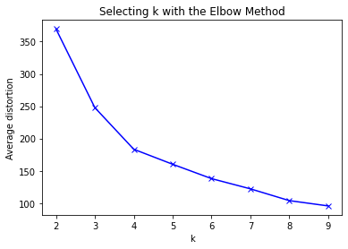

```python
#Finding optimal no. of clusters
from scipy.spatial.distance import cdist
clusters=range(2,10)
meanDistortions=[]

for k in clusters:
    model=KMeans(n_clusters=k)
    model.fit(fdataattr)
    prediction=model.predict(fdataattr)
    meanDistortions.append(sum(np.min(cdist(fdataattr, model.cluster_centers_, 'euclidean'), axis=1)) / fdataattr.shape[0])


plt.plot(clusters, meanDistortions, 'bx-')
plt.xlabel('k')
plt.ylabel('Average distortion')
plt.title('Selecting k with the Elbow Method')
```

```python
kmeans = KMeans(n_clusters=3, n_init = 15, random_state=2345)
```

```python
kmeans.fit(fdata_z)
```

```
KMeans(n_clusters=3, n_init=15, random_state=2345)
```

```python
centroids = kmeans.cluster_centers_
```

```python
centroid_df = pd.DataFrame(centroids, columns = list(fdata_z) )
```

```python
df_labels = pd.DataFrame(kmeans.labels_ , columns = list(['labels']))

df_labels['labels'] = df_labels['labels'].astype('category')
```

```python
# Joining the label dataframe with the data frame.
df_labeled = fdataattr.join(df_labels)
df_labeled['labels'].value_counts()
```

```
1    161
2    137
0    100
Name: labels, dtype: int64
```

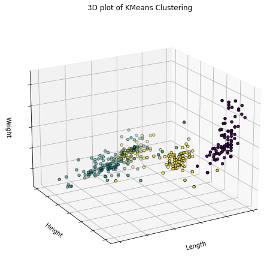

```python
from mpl_toolkits.mplot3d import Axes3D
fig = plt.figure(figsize=(8, 6))
ax = Axes3D(fig, rect=[0, 0, .95, 1], elev=20, azim=60)
kmeans.fit(fdata_z)
labels = kmeans.labels_
ax.scatter(fdata_z.iloc[:, 0], fdata_z.iloc[:, 1], fdata_z.iloc[:, 3],c=labels.astype(np.float), edgecolor='k')
ax.w_xaxis.set_ticklabels([])
ax.w_yaxis.set_ticklabels([])
ax.w_zaxis.set_ticklabels([])
ax.set_xlabel('Length')
ax.set_ylabel('Height')
ax.set_zlabel('Weight')
ax.set_title('3D plot of KMeans Clustering')
```

```python
vehicle_df = pd.read_csv("vehicle.csv")
vehicle_df.shape
```

```
(846, 19)
```

```python
vehicle_df.sample(10)
```

|  | compactness | circularity | distance_circularity | radius_ratio | pr.axis_aspect_ratio | max.length_aspect_ratio | scatter_ratio | elongatedness | pr.axis_rectangularity | max.length_rectangularity | scaled_variance | scaled_variance.1 | scaled_radius_of_gyration | scaled_radius_of_gyration.1 | skewness_about | skewness_about.1 | skewness_about.2 | hollows_ratio | class |
| --- | --- | --- | --- | --- | --- | --- | --- | --- | --- | --- | --- | --- | --- | --- | --- | --- | --- | --- | --- |
| 232 | 81 | 44.0 | 68.0 | 120.0 | 53.0 | 6 | 151.0 | 45.0 | 19.0 | 147 | 170.0 | 333.0 | 178.0 | 86.0 | 4.0 | 5.0 | 179.0 | 183 | bus |
| 769 | 91 | 36.0 | 83.0 | 162.0 | 61.0 | 8 | 142.0 | 47.0 | 19.0 | 128 | 163.0 | 298.0 | 137.0 | 63.0 | 0.0 | 31.0 | 193.0 | 200 | car |
| 361 | 101 | 46.0 | 105.0 | 195.0 | 61.0 | 10 | 198.0 | 34.0 | 23.0 | 150 | 213.0 | 578.0 | 195.0 | 66.0 | 7.0 | 38.0 | 192.0 | 205 | car |
| 33 | 101 | 48.0 | 107.0 | 222.0 | 68.0 | 10 | 208.0 | 32.0 | 24.0 | 154 | 232.0 | 641.0 | 204.0 | 70.0 | 5.0 | 38.0 | 190.0 | 202 | car |
| 165 | 103 | 54.0 | 91.0 | 179.0 | 57.0 | 11 | 220.0 | 31.0 | 25.0 | 170 | 220.0 | 707.0 | 198.0 | 72.0 | 1.0 | 32.0 | 186.0 | 198 | car |
| 526 | 97 | 44.0 | 95.0 | 202.0 | 66.0 | 9 | 188.0 | 35.0 | 22.0 | 144 | 216.0 | 526.0 | 175.0 | 72.0 | 15.0 | 11.0 | 190.0 | 197 | car |
| 710 | 102 | 54.0 | 98.0 | 201.0 | 61.0 | 6 | 225.0 | 29.0 | 25.0 | 165 | 246.0 | 766.0 | 231.0 | 79.0 | 9.0 | 14.0 | 188.0 | 187 | bus |
| 259 | 98 | 58.0 | 101.0 | 208.0 | 65.0 | 12 | 226.0 | 30.0 | 25.0 | 182 | 225.0 | 748.0 | 216.0 | 71.0 | 6.0 | 1.0 | 185.0 | 196 | car |
| 7 | 90 | 43.0 | 66.0 | 157.0 | 65.0 | 9 | 137.0 | 48.0 | 18.0 | 146 | 162.0 | 281.0 | 164.0 | 67.0 | 3.0 | 3.0 | 193.0 | 202 | van |
| 650 | 98 | 55.0 | 104.0 | 213.0 | 67.0 | 9 | 206.0 | 32.0 | 23.0 | 167 | 223.0 | 629.0 | 220.0 | 72.0 | 5.0 | 19.0 | 187.0 | 196 | car |

```python
print("Feature-wise percentage of Null values :{0}".format(vehicle_df.isnull().sum() * 100 / len(vehicle_df)))
```

```
Feature-wise percentage of Null values :compactness                    0.000000
circularity                    0.591017
distance_circularity           0.472813
radius_ratio                   0.709220
pr.axis_aspect_ratio           0.236407
max.length_aspect_ratio        0.000000
scatter_ratio                  0.118203
elongatedness                  0.118203
pr.axis_rectangularity         0.354610
max.length_rectangularity      0.000000
scaled_variance                0.354610
scaled_variance.1              0.236407
scaled_radius_of_gyration      0.236407
scaled_radius_of_gyration.1    0.472813
skewness_about                 0.709220
skewness_about.1               0.118203
skewness_about.2               0.118203
hollows_ratio                  0.000000
class                          0.000000
dtype: float64
```

```python
vehicle_df['circularity'].fillna(vehicle_df['circularity'].mean(), inplace = True)
vehicle_df['distance_circularity'].fillna(vehicle_df['distance_circularity'].mean(), inplace = True)
vehicle_df['radius_ratio'].fillna(vehicle_df['radius_ratio'].mean(), inplace = True)
vehicle_df['pr.axis_aspect_ratio'].fillna(vehicle_df['pr.axis_aspect_ratio'].mean(), inplace = True)
vehicle_df['scatter_ratio'].fillna(vehicle_df['scatter_ratio'].mean(), inplace = True)
vehicle_df['elongatedness'].fillna(vehicle_df['elongatedness'].mean(), inplace = True)
vehicle_df['pr.axis_rectangularity'].fillna(vehicle_df['pr.axis_rectangularity'].mean(), inplace = True)
vehicle_df['scaled_variance'].fillna(vehicle_df['scaled_variance'].mean(), inplace = True)
vehicle_df['scaled_variance.1'].fillna(vehicle_df['scaled_variance'].mean(), inplace = True)
vehicle_df['scaled_radius_of_gyration'].fillna(vehicle_df['scaled_radius_of_gyration'].mean(), inplace = True)
vehicle_df['scaled_radius_of_gyration.1'].fillna(vehicle_df['scaled_radius_of_gyration.1'].mean(), inplace = True)
vehicle_df['skewness_about'].fillna(vehicle_df['skewness_about'].mean(), inplace = True)
vehicle_df['skewness_about.1'].fillna(vehicle_df['skewness_about.1'].mean(), inplace = True)
vehicle_df['skewness_about.2'].fillna(vehicle_df['skewness_about.2'].mean(), inplace = True)
```

[figure not shown]

```python
labels = vehicle_df['class'].unique()
itm=vehicle_df['class'].value_counts()

fig1, ax1 = plt.subplots()
ax1.pie(itm,labels=labels, autopct='%1.1f%%',
shadow=True, startangle=90)
ax1.axis('equal')  # Equal aspect ratio ensures that pie is drawn as a circle.
ax1.set_title("Class Distribution")
plt.show()
```

```python
dup= vehicle_df.duplicated()
sum(dup)
```

```
0
```

```python
X = vehicle_df.drop(labels= "class" , axis = 1)
Y = vehicle_df["class"]
X.head()
X_sd = StandardScaler().fit_transform(X)
```

```python
clf = svm.SVC(kernel='linear')
clf.fit(X_sd , Y)
svc_predict = clf.predict(X_sd)
```

```python
print(classification_report(Y,svc_predict,labels=["bus","car","van"]))
```

```
              precision    recall  f1-score   support

         bus       0.93      0.95      0.94       218
         car       0.97      0.96      0.96       429
         van       0.96      0.97      0.96       199

    accuracy                           0.96       846
   macro avg       0.95      0.96      0.96       846
weighted avg       0.96      0.96      0.96       846
```

```python
pca = PCA(n_components=10)
pca.fit(X_sd)
```

```
PCA(n_components=10)
```

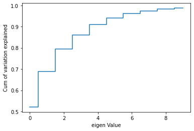

```python
plt.step(list(range(0,10)),np.cumsum(pca.explained_variance_ratio_), where='mid')
plt.ylabel('Cum of variation explained')
plt.xlabel('eigen Value')
plt.show()
```

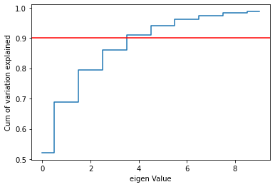

```python
plt.step(list(range(0,10)),np.cumsum(pca.explained_variance_ratio_), where='mid')
plt.ylabel('Cum of variation explained')
plt.xlabel('eigen Value')
plt.axhline(y = 0.9, color = 'r', linestyle = '-')
plt.show()
```

```python
pca_min = PCA(n_components=5)
pca_min.fit(X_sd)
```

```
PCA(n_components=5)
```

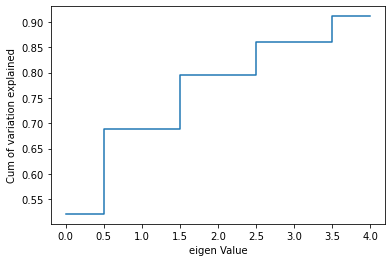

```python
plt.step(list(range(0,5)),np.cumsum(pca_min.explained_variance_ratio_), where='mid')
plt.ylabel('Cum of variation explained')
plt.xlabel('eigen Value')
plt.show()
```

```python
clf2 = svm.SVC(kernel='linear', C=5)
clf2.fit(X_sd , Y)
svc_predict2 = clf2.predict(X_sd)
```

```python
print(classification_report(Y,svc_predict2,labels=["bus","car","van"]))
```

```
              precision    recall  f1-score   support

         bus       0.96      0.98      0.97       218
         car       0.99      0.97      0.98       429
         van       0.97      0.97      0.97       199

    accuracy                           0.98       846
   macro avg       0.97      0.98      0.97       846
weighted avg       0.98      0.98      0.98       846
```

```python
clf3 = svm.SVC(gamma=0.025, C=4)
clf3.fit(X_sd , Y)
svc_predict3 = clf3.predict(X_sd)
```

```python
print(classification_report(Y,svc_predict3,labels=["bus","car","van"]))
```

```
              precision    recall  f1-score   support

         bus       0.99      0.98      0.98       218
         car       0.99      0.99      0.99       429
         van       0.96      0.98      0.97       199

    accuracy                           0.98       846
   macro avg       0.98      0.98      0.98       846
weighted avg       0.98      0.98      0.98       846
```

Assumptions in PCA

- There must be linearity in the data set, i.e. the variables combine in a linear manner to form the dataset. The variables exhibit relationships among themselves.
- PCA assumes that the principal component with high variance must be paid attention and the PCs with lower variance are disregarded as noise. Pearson correlation coefficient framework led to the origin of PCA, and there it was assumed first that the axes with high variance would only be turned into principal components.
- All variables should be accessed on the same ratio level of measurement. The most preferred norm is at least 150 observations of the sample set with a ratio measurement of 5:1.
- Extreme values that deviate from other data points in any dataset, which are also called outliers, should be less. More number of outliers will represent experimental errors and will degrade your ML model/algorithm.
- The feature set must be correlated and the reduced feature set after applying PCA will represent the original data set but in an effective way with fewer dimensions.

Advantages of PCA

- Removes Correlated Features:- After implementing the PCA on your dataset, all the Principal Components are independent of one another. There is no correlation among them.
- Improves Algorithm Performance:- If the input dimensions are too high, then using PCA to speed up the algorithm is a reasonable choice.
- Improves Visualization :- It is very hard to visualize and understand the data in high dimensions. PCA transforms a high dimensional data to low dimensional data (2 dimension) so that it can be visualized easily.
- Reduces Overfitting:- Overfitting mainly occurs when there are too many variables in the dataset. So, PCA helps in overcoming the overfitting issue by reducing the number of features.

Limitations of PCA

- Independent variables become less interpretable:- After implementing PCA on the dataset, your original features will turn into Principal Components. Principal Components are the linear combination of your original features. Principal Components are not as readable and interpretable as original features.
- Data standardization is must before PCA:-You must standardize your data before implementing PCA, otherwise PCA will not be able to find the optimal Principal Components.Also,for standardization, all the categorical features are required to be converted into numerical features before PCA can be applied.
- Information Loss:-Although Principal Components try to cover maximum variance among the features in a dataset, if we don’t select the number of Principal Components with care, it may miss some information as compared to the original list of features.